# Multiple Linear Regression

Examples using R

Ranadeep Daw

2024-10-18

# Question 1: MLR

### Let’s again go back to the OzDASL website to download the **Cheese Taste** data. Metadata link is [here](https://lib.stat.cmu.edu/DASL/Datafiles/Cheese.html). Following code downloads the same data from a different site in a dataframe called $\texttt{cheese_data}$ that has the data from the above link.

```r
cheese_data = read.csv(url("https://raw.githubusercontent.com/dawranadeep/24FA_git/refs/heads/main/Practice_qns/img/cheese_data.csv"))
```

### Look how the first few rows of the data look like:

```r
head(cheese_data)
```

```
##   taste Acetic   H2S Lactic
## 1  12.3  4.543 3.135   0.86
## 2  20.9  5.159 5.043   1.53
## 3  39.0  5.366 5.438   1.57
## 4  47.9  5.759 7.496   1.81
## 5   5.6  4.663 3.807   0.99
## 6  25.9  5.697 7.601   1.09
```

### A. Draw all the scatterplots between the response variable **taste** and the other predictors. Any comments on the plots?

**Answer:**

Creating one plot at a time helps us visualize them more clearly. In the following examples, I include additional options like $\texttt{pch}$ and $\texttt{col}$ – these are not essential but enhance the appearance of the plots. Additionally, note that $\texttt{xlab}$ and $\texttt{ylab}$ set the axis labels, while $\texttt{main}$ adds a heading to the scatterplot.

```r
Taste = cheese_data$taste
Acetic = cheese_data$Acetic
H2S = cheese_data$H2S
Lactic = cheese_data$Lactic
```

Now, let’s do the scatterplots.

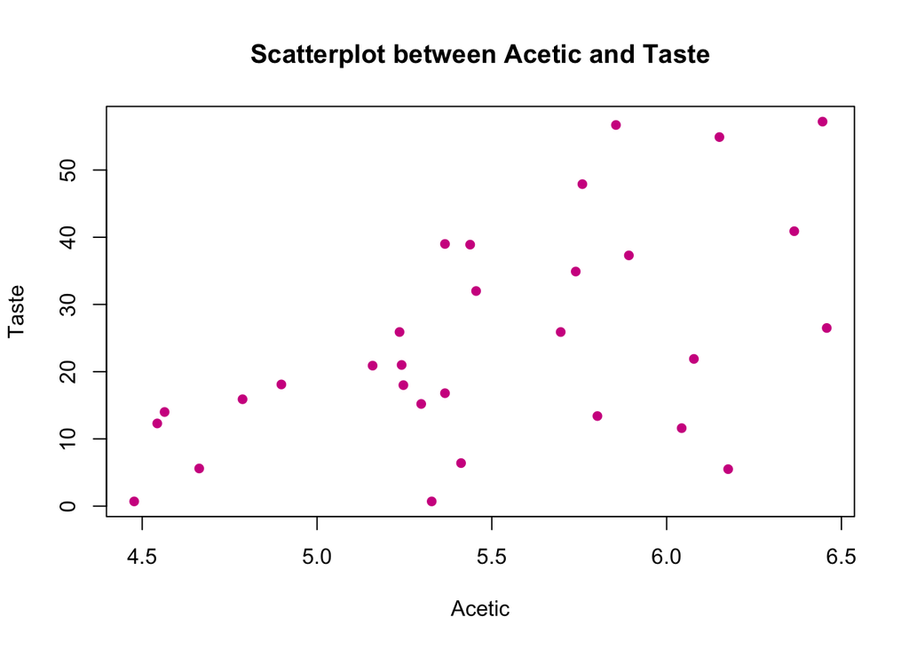

```r
# Scatterplot between Acetic and Taste
plot(  Acetic, Taste, xlab = "Acetic", ylab = "Taste",
       main = "Scatterplot between Acetic and Taste",
       pch = 16, col = "violetred")
```

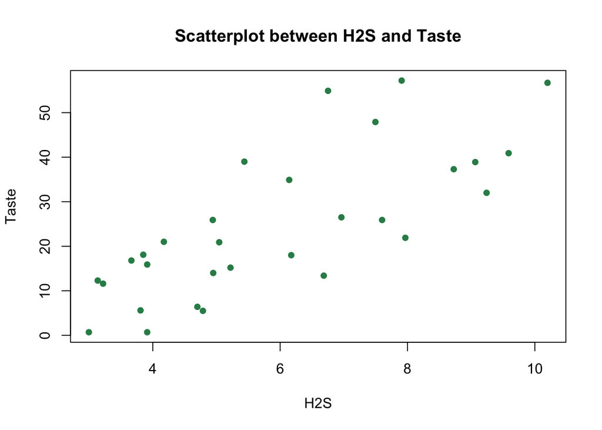

```r
# Scatterplot between H2S and Taste
plot(  H2S, Taste, xlab = "H2S", ylab = "Taste",
       main = "Scatterplot between H2S and Taste",
       pch = 16, col = "seagreen")
```

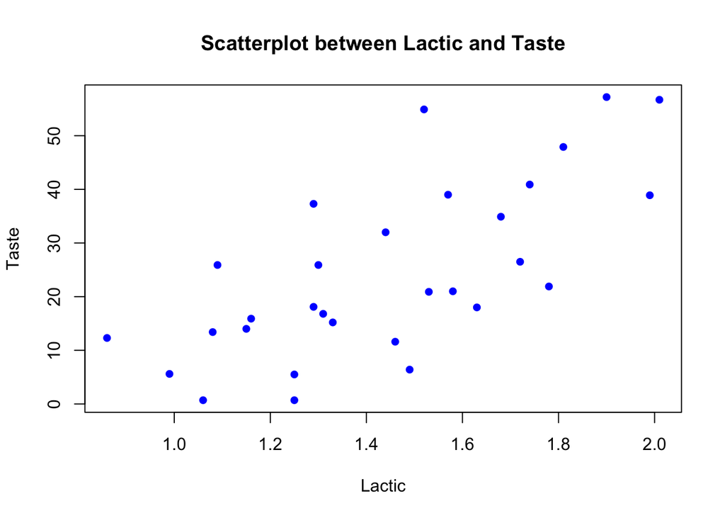

```r
# Scatterplot between Lactic and Taste
plot(  Lactic, Taste, xlab = "Lactic", ylab = "Taste",
       main = "Scatterplot between Lactic and Taste",
       pch = 16, col = "blue")
```

The scatterplots show that every predictor variable has an overall positive or increasing trend with respect to the response, $\texttt{Taste}$. Between $\texttt{H2S}$ and $\texttt{Taste}$, the trend seems linear with a relatively stronger relationship compared to the other predictors. $\texttt{Lactic}$ also exhibits an overall increasing trend with a linear pattern, however, the variability in the response variable in considerably high. $\texttt{Acetic}$ although show an overall weak increasing trend, it is evident that the response variable has no clear trend once the predictor goes beyond $5.5$.

### B. Build the multiple linear regression model with **taste** as the response and other variables as predictors. Write down the fitted equation.

**Answer:**

```r
# Recall, <model> = lm(<y> ~ <x1> + ..., data = <data>)
mlr_model = lm( taste ~ Acetic + H2S + Lactic, data = cheese_data)
mlr_model
```

```
##
## Call:
## lm(formula = taste ~ Acetic + H2S + Lactic, data = cheese_data)
##
## Coefficients:
## (Intercept)       Acetic          H2S       Lactic
##    -28.8768       0.3277       3.9118      19.6705
```

$$\begin{align*}
\widehat{\text{Taste}} = -28.8768 + 0.3277 * \text{Acetic} + 3.9118 *
\text{H2S} + 19.6705 * \text{Lactic}
\end{align*}$$

If I ask you to interpret the coefficients:

- $-28.8768$ is the estimated mean value of $\texttt{Taste}$ when all the predictors are set to $0$.
- Keeping $\texttt{H2S}$ and $\texttt{Lactic}$ same, if I increase the value of $\texttt{Acetic}$ by $1$ unit, the estimated mean value of $\texttt{Taste}$ increases by $0.3277$.
- Rest follows similarly as the last one.

### C. What are the $R^2$ and adjusted $R^2$? Is this model significant?

**Answer:**

```r
summary(mlr_model)
```

```
##
## Call:
## lm(formula = taste ~ Acetic + H2S + Lactic, data = cheese_data)
##
## Residuals:
##     Min      1Q  Median      3Q     Max
## -17.390  -6.612  -1.009   4.908  25.449
##
## Coefficients:
##             Estimate Std. Error t value Pr(>|t|)
## (Intercept) -28.8768    19.7354  -1.463  0.15540
## Acetic        0.3277     4.4598   0.073  0.94198
## H2S           3.9118     1.2484   3.133  0.00425 **
## Lactic       19.6705     8.6291   2.280  0.03108 *
## ---
## Signif. codes:  0 '***' 0.001 '**' 0.01 '*' 0.05 '.' 0.1 ' ' 1
##
## Residual standard error: 10.13 on 26 degrees of freedom
## Multiple R-squared:  0.6518, Adjusted R-squared:  0.6116
## F-statistic: 16.22 on 3 and 26 DF,  p-value: 3.81e-06
```

- Multiple R-squared: $0.6518$.
- Adjusted R-squared: $0.6116$.
- Model significance test:
  - $H_0$: $\beta_1 = \beta_2 = \beta_3 = 0$; $H_A$: At least one of the coefficients are not $0$.
  - Let’s test at level $\alpha = 0.05$.
  - $p$-value: $3.81e-06$ < $\alpha$ = 0.05. So, we can reject the null hypothesis model is significant.

### D. Test for $H_0: \beta_1 = 0$ vs $H_A: \beta_1 \neq 0$. Take $\alpha = 0.05$.

**Answer:**

- $H_0$: $\beta_1 = 0$; $H_A$: $\beta_1 \neq 0$.
- $p$-value = $0.94198$ > $\alpha = 0.05$; Hence, can not reject $H_0$.

### E. Test for $H_0: \beta_2 = 0$ vs $H_A: \beta_2 \neq 0$. Take $\alpha = 0.05$.

**Answer:**

- $H_0$: $\beta_1 = 0$; $H_A$: $\beta_1 \neq 0$.
- $p$-value = $0.00425$ < $\alpha = 0.05$; Hence, reject $H_0$.

### F. Find the $95\%$ confidence intervals of the estimated coefficients. Can you perform the tests in part D and E from this CI?

**Answer:**

```r
# 95% CI
confint( mlr_model, level = 0.95)
```

```
##                  2.5 %    97.5 %
## (Intercept) -69.443503 11.689964
## Acetic       -8.839420  9.494902
## H2S           1.345656  6.478026
## Lactic        1.933267 37.407820
```

- The $95\%$ CI for $\beta_1$ is $(-8.84, 9.49)$. Since we are testing for $0$, we need to check if $0$ is inside the CI or not. Since $0$ is inside, we fail to reject $H_0$.
- The $95\%$ CI for $\beta_2$ is $(1.35, 6.48)$. Since $0$ is not inside the CI, we reject $H_0$.

### G. Do the residual-vs-fitted plot. Can you comment anything on the residual?

**Answer:**

You can directly plot the residual against fitted values plot by using the following:

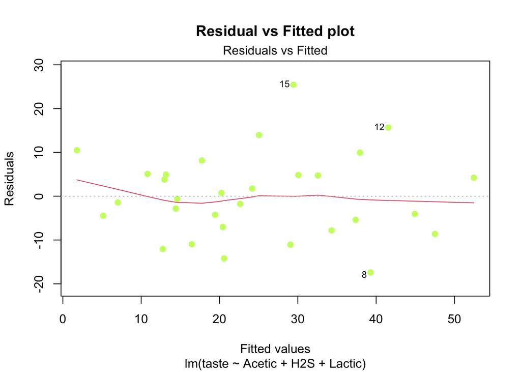

```r
plot(mlr_model, which = 1,
     col="darkolivegreen1", pch=19,
     main = "Residual vs Fitted plot")
```

Note that the red line is known as the LOESS line, a nonlinear model that smooths the residuals to help identify any underlying patterns.

Alternatively, if you ask ChatGPT, it produces the same answer in a slightly complicated way, without the LOESS fit:

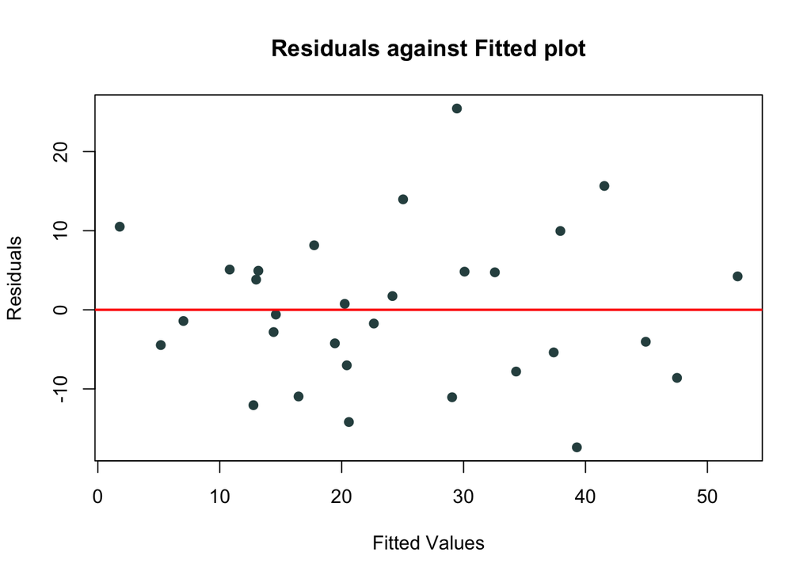

```r
# ChatGPT produced result

plot(fitted(mlr_model), residuals(mlr_model),
     xlab = "Fitted Values",
     ylab = "Residuals",
     main = "Residuals against Fitted plot",
     pch = 19, col = "darkslategrey")

# Add a horizontal line at y=0
abline(h = 0, col = "red", lwd = 2)
```

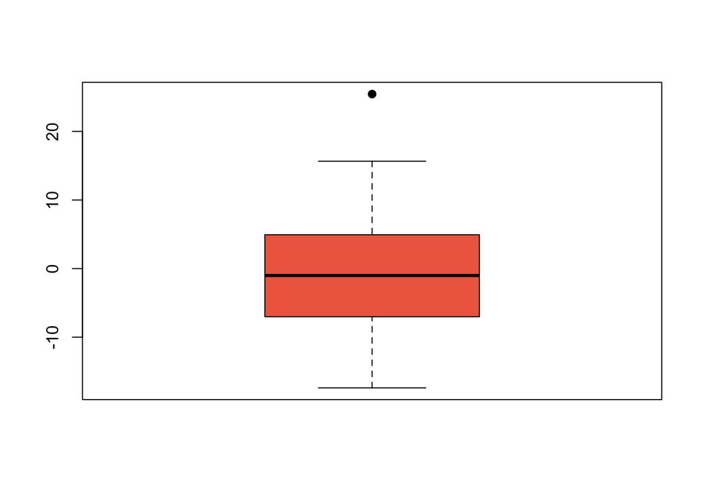

```r
boxplot(residuals(mlr_model),
        col = "coral2", pch = 19)
```

As the boxplot suggests, there seems to be an outlier on the higher side.

### H. Do the QQ-plot of the residual. Can you comment anything about normality?

**Answer:**

Let’s first try the QQ-plot. We will try to first guess normality based on the plot.

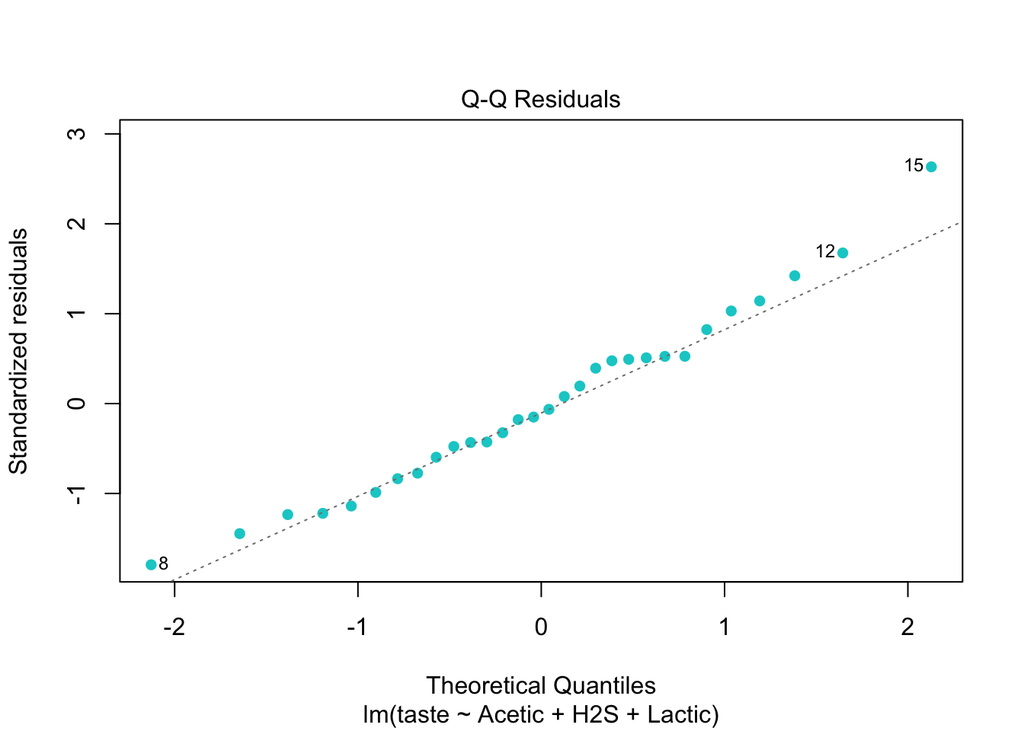

```r
plot(mlr_model, which = 2, pch = 16, col = "cyan3")
```

The plot seems quite likely to follow normal distribution. The line seems to have a $45^{\circ}$ angle, and poinst seem to closely follow the qqline. However, we will now try the Shapiro-Wilk test to formally check about our guess. In this test, the null hypothesis is that the residuals are normally distributed. Let’s apply it to our model.

```r
shapiro.test(  residuals(mlr_model))
```

```
##
##  Shapiro-Wilk normality test
##
## data:  residuals(mlr_model)
## W = 0.98021, p-value = 0.8312
```

Let’s test at $\alpha = 0.05$. The $p$-value = $0.8312$ > $\alpha$. Hence, we fail to reject the null hypothesis that residuals are normally distributed.

### I. Let’s try to do backward selction using the $p$ values. How would you update the model?

**Answer:**

Referring back to the coefficient table from part C, we see that $\texttt{Acetic}$ has the highest $p$-value and is not significant at level $\alpha = 0.05$. Therefore, we can exclude this variable and fit a new model:

```r
mlr_model2 = lm( taste ~ H2S + Lactic, data = cheese_data)
summary(mlr_model2)
```

```
##
## Call:
## lm(formula = taste ~ H2S + Lactic, data = cheese_data)
##
## Residuals:
##     Min      1Q  Median      3Q     Max
## -17.343  -6.530  -1.164   4.844  25.618
##
## Coefficients:
##             Estimate Std. Error t value Pr(>|t|)
## (Intercept)  -27.592      8.982  -3.072  0.00481 **
## H2S            3.946      1.136   3.475  0.00174 **
## Lactic        19.887      7.959   2.499  0.01885 *
## ---
## Signif. codes:  0 '***' 0.001 '**' 0.01 '*' 0.05 '.' 0.1 ' ' 1
##
## Residual standard error: 9.942 on 27 degrees of freedom
## Multiple R-squared:  0.6517, Adjusted R-squared:  0.6259
## F-statistic: 25.26 on 2 and 27 DF,  p-value: 6.551e-07
```

In this updated model, all predictors are significant at the $\alpha = 0.05$ level, making this my final choice after performing backward selection based on the $p$-value criterion.

### J. Now do the backward selction using the $\texttt{step}$ function from $\texttt{R}$. What is the final model?

**Answer:**

Recall, variable selection can also be done automatically using the $\text{step}$ function, but this time the stopping criterion is the AIC.

```r
backward_model = step(mlr_model, direction = "backward")
```

```
## Start:  AIC=142.64
## taste ~ Acetic + H2S + Lactic
##
##          Df Sum of Sq    RSS    AIC
## - Acetic  1      0.55 2669.0 140.65
## <none>                2668.4 142.64
## - Lactic  1    533.32 3201.7 146.11
## - H2S     1   1007.66 3676.1 150.25
##
## Step:  AIC=140.65
## taste ~ H2S + Lactic
##
##          Df Sum of Sq    RSS    AIC
## <none>                2669.0 140.65
## - Lactic  1    617.18 3286.1 144.89
## - H2S     1   1193.52 3862.5 149.74
```

```r
summary(backward_model)
```

```
##
## Call:
## lm(formula = taste ~ H2S + Lactic, data = cheese_data)
##
## Residuals:
##     Min      1Q  Median      3Q     Max
## -17.343  -6.530  -1.164   4.844  25.618
##
## Coefficients:
##             Estimate Std. Error t value Pr(>|t|)
## (Intercept)  -27.592      8.982  -3.072  0.00481 **
## H2S            3.946      1.136   3.475  0.00174 **
## Lactic        19.887      7.959   2.499  0.01885 *
## ---
## Signif. codes:  0 '***' 0.001 '**' 0.01 '*' 0.05 '.' 0.1 ' ' 1
##
## Residual standard error: 9.942 on 27 degrees of freedom
## Multiple R-squared:  0.6517, Adjusted R-squared:  0.6259
## F-statistic: 25.26 on 2 and 27 DF,  p-value: 6.551e-07
```

So, again the final selected model is the same as in part I.

### K. Comparing adjusted $R^2$, which model would you prefer?

**Answer:**

- Initial Model: $\text{Taste} = \beta_0 + \beta_1 * \text{Acetic} + \beta_2 * \text{H2S} + \beta_3 * \text{Lactic} + \epsilon_i$.
  - Multiple R-squared: **$0.6518$**.
  - Adjusted R-squared: **$0.6116$**.
- Model 2: $\text{Taste} = \beta_0 + \beta_1 * \text{H2S} + \beta_2 * \text{Lactic} + \epsilon_i$.
  - Multiple R-squared: **$0.6517$**.
  - Adjusted R-squared: **$0.6259$**.

Remember that to compare between different models, we should use the adjusted $R^2$ value. Hence, here our second model is the preferred one by following adjusted $R^2$.

# Question 2: Polynomial Regression and Model Selection

### Let’s again go back to the OzDASL website to download the **Sound Pressure of Dolphin Sonar** data. Metadata link is [see here](http://www.statsci.org/data/general/dolphin.html). Following code downloads the data in a dataframe called $\texttt{dolphin_data}$ and shows a snapshot.

```r
dolphin_data = read.table(url("http://www.statsci.org/data/general/dolphin.txt"), header = TRUE)
head(dolphin_data)
```

```
##   Range SoundPressure
## 1   8.5         201.2
## 2   9.1         204.3
## 3  10.8         208.5
## 4  12.0         231.7
## 5   8.9         213.4
## 6   9.3         213.2
```

### A. We’ll use Range as $x$ and SoundPressure as $y$. Draw the scatterplot. What kind of model do you think you can build here?

**Answer:**

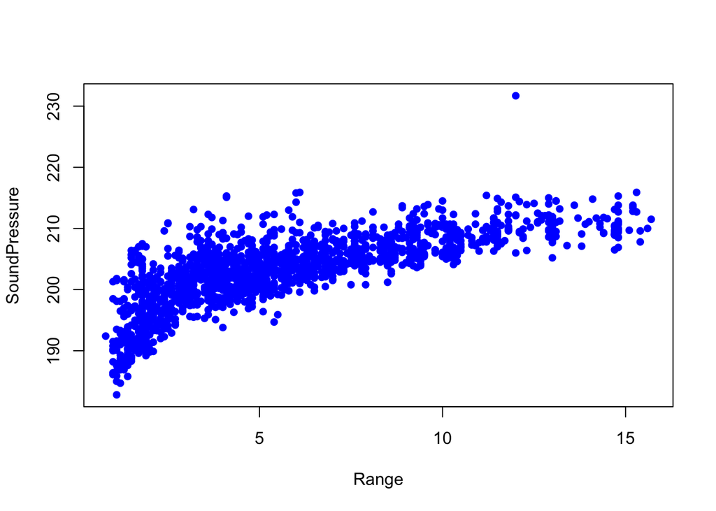

```r
Range = dolphin_data$Range
SoundPressure = dolphin_data$SoundPressure

plot(Range, SoundPressure, pch = 16, col = "blue")
```

Carefully note that in the scatterplot, there is an outlier. Also, the pattern is not exactly linear, but shows some evidence of curvy pattern between the two variables.

Note that, the curve seems to look like the $y = \log(x)$ shape. In more advanced Statistics courses, you will learn how to fit different models depending on the type of scatterplot. However, for now, we will focus on fitting a polynomial or quadratic model in the next section.

### B. First, build a linear regression model. What are the $R^2$ and adjusted $R^2$? Is this model significant?

**Answer:**

We want to fit the model: $\text{SoundPressure} = \beta_0 + \beta_1 * \text{Range} + \epsilon$.

```r
mod_linear = lm(SoundPressure ~ Range, data = dolphin_data)
summary(mod_linear)
```

```
##
## Call:
## lm(formula = SoundPressure ~ Range, data = dolphin_data)
##
## Residuals:
##      Min       1Q   Median       3Q      Max
## -14.5584  -2.1279  -0.1548   2.2862  20.8054
##
## Coefficients:
##              Estimate Std. Error t value Pr(>|t|)
## (Intercept) 195.99231    0.18196 1077.11   <2e-16 ***
## Range         1.24186    0.02757   45.05   <2e-16 ***
## ---
## Signif. codes:  0 '***' 0.001 '**' 0.01 '*' 0.05 '.' 0.1 ' ' 1
##
## Residual standard error: 3.821 on 1632 degrees of freedom
## Multiple R-squared:  0.5542, Adjusted R-squared:  0.554
## F-statistic:  2029 on 1 and 1632 DF,  p-value: < 2.2e-16
```

- $R^2 = 0.5542$.
- Adjusted $R^2 = 0.554$.
- $H_0$: $\beta_1 = 0$ vs $H_A: \beta_1 \neq 0$. Since we are testing for model significance, we will go to the last line. Test statistic: $F = 2029$. $p$-value $\approx 0 < 0.05$. So, $H_0$ is rejected and the model is significant.

Let’s now visualize how good the model fits the scatterplot:

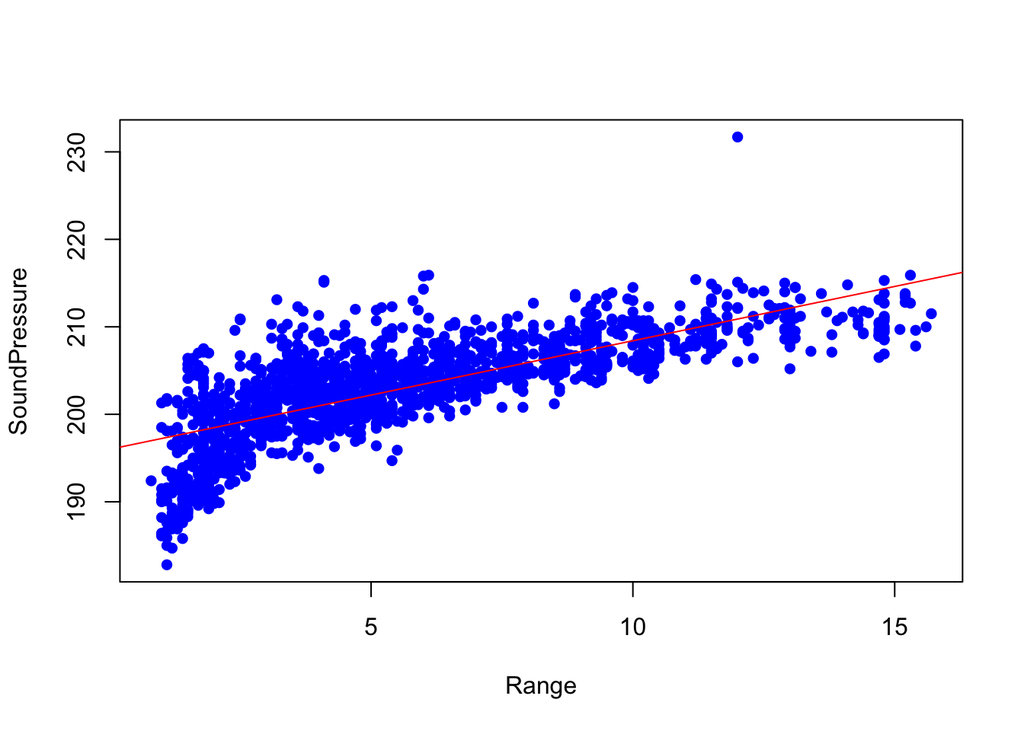

```r
plot(Range, SoundPressure, pch = 16, col = "blue")
abline(mod_linear, col = "red")
```

Notice that the rapidly increasing pattern on the far left side is not captured by the model. Since we only used a linear model, the line fails to account for this relationship Therefore, next, we will try to improve the model to address this.